# Tema 4 - Introducción a varias variables aleatorias

## Varias variables aleatorias

## Introducción

Muchos experimentos aleatorios involucran varias variables aleatorias.

Por ejemplo, dado un individuo de 30 años escogido al azar de una cierta población, medir su altura y su peso conjuntamente.

Otro ejemplo más complejo sería la medición continuada de un *fenómeno aleatorio* que se repite en el tiempo, como sería medir la temperatura media un día determinado del año, por ejemplo el día 1 de enero en un cierto lugar.

La variable aleatoria que nos da la medición en 10 años sería una variable aleatoria de varias variables que involucra 10 variables aleatorias supuestas independientes e idénticamente distribuïdas, lo que en **estadística inferencial** se le llama una **muestra aleatoria simple**.

## Dos variables aleatorias. Definición

Recordemos que una **variable aleatoria** \(X\) es una aplicación que toma valores numéricos para cada resultado de un experimento aleatorio: \[ \begin{array}{rl} X: \Omega & \longrightarrow \mathbb{R}\\ w & \longrightarrow X(w). \end{array} \] A partir de la definición anterior, generalizamos la noción de **variable aleatoria unidimensional** a **variable aleatoria bidimensional**:

Definición de variable aleatoria bidimensional: Dado un experimento aleatorio con **espacio muestral** \(\Omega\), definimos **variable aleatoria bidimensional** \((X,Y)\) a toda aplicación \[ \begin{array}{rl} X: \Omega & \longrightarrow \mathbb{R}^2\\ w & \longrightarrow (X(w),Y(w)). \end{array} \]

## Dos variables aleatorias. Ejemplos

**Ejemplo**

Consideremos el experimento aleatorio de lanzar dos dados no trucados.

Sea \(S\) la suma de los resultados obtenidos y \(P\) el producto de los mismos.

La variable aleatoria \((S,P)\) que asigna a cada resultado \(w=(x_1,x_2)\) donde \(x_1\) es el resultado obtenido per el primer dado y \(x_2\), el resultado obtenido por el segundo los valores: \(S(w)=x_1+x_2\) y \(P(w)=x_1\cdot x_2\) seria una variable aleatoria bidimensional.

El suceso \(\{2\leq S\leq 4,\ 3\leq P\leq 6\}\) seria: \[ \{2\leq S\leq 4,\ 3\leq P\leq 6\} = \{(1,3),(3,1),(2,2)\}. \]

**Ejemplo**

Consideremos el experimento aleatorio de elegir al azar un estudiante de primer curso de grado. Sea \(w\) el estudiante elegido. Consideremos la variable aleatoria \((H,W)\) que asigna a dicho estudiante \(w\), \(H(w):\) la altura de dicho estudiante en cm. y \(W(w):\) el peso de dicho estudiante en kg.

Estamos interesado en sucesos del tipo \(A=\{H\leq 176,\ W\leq 85\}\), o sea, el conjunto de estudiantes que miden menos de 1.76 m. y que pesan menos de 85 kg.

## Dos variables aleatorias. Introducción

Los sucesos que se derivan de una **variable aleatoria bidimensional** estan especificados por regiones del plano. Veamos algunos ejemplos:

Suceso: \(\{X+Y\leq 1\}\). Sería la zona sombreada del gráfico siguiente:

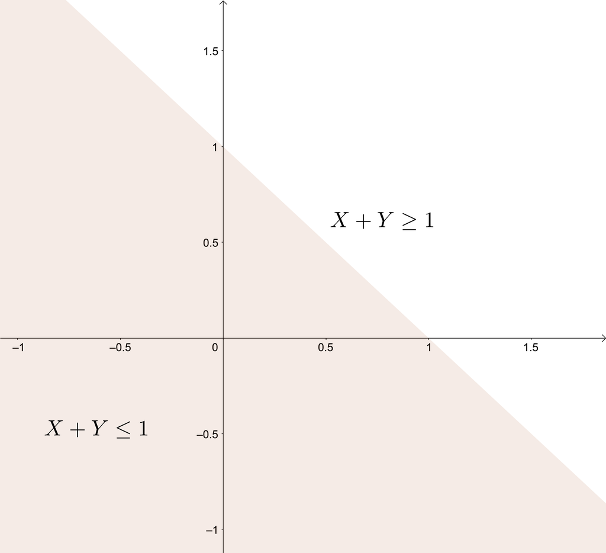

## Dos variables aleatorias. Introducción

Suceso: \(\{X^2+Y^2\leq 4\}\). Sería la zona sombreada del gráfico siguiente:

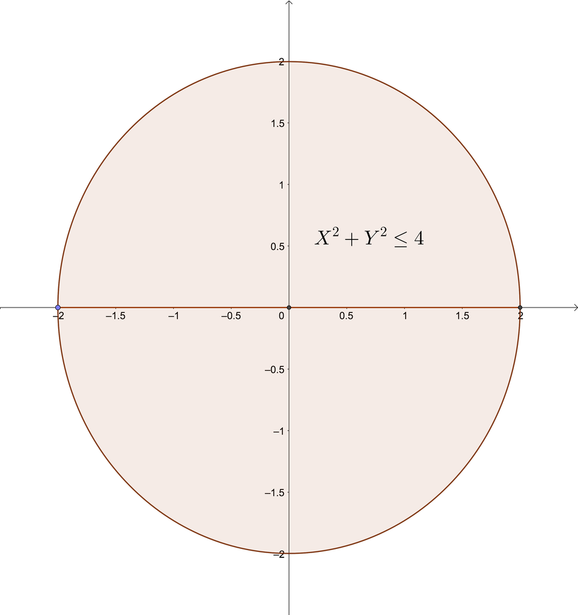

## Dos variables aleatorias. Introducción

[figure not shown]

## Dos variables aleatorias. Introducción

La probabilidad de que la **variable bidimensional** pertenezca a una cierta **región del plano \(B\)** se define de la forma siguiente: \[ P((X,Y)\in B)=P\{w\in \Omega,\ |\ (X(w),Y(w))\in B\}, \] o sea, la probabilidad anterior es la probabilidad del suceso formado por los elementos de \(w\in\Omega\) que cumplen que su **imagen** por la **variable aleatoria bidimensional \((X,Y)\)** esté en \(B\).

Por ejemplo, si consideramos \(B=\{X+Y\leq 1\}\), \(P((X,Y)\in B)\) sería la probabilidad del suceso formado por los elementos \(w\) de \(\Omega\) tal que la suma de las imágenes por \(X\) e \(Y\) sea menor o igual que 1: \(X(w)+Y(w)\leq 1\).

## Función de distribución conjunta

## Función de distribución conjunta. Introducción

Dada una **variable aleatoria bidimensional** \((X,Y)\), queremos estudiar cómo se distruye la probabilidad de sucesos cualesquiera de la forma \(\{(X,Y)\in B\}\), donde \(B\) es una región del plano.

Para ello, definimos la **función de distribución conjunta**:

Definión de función de distribución conjunta: Dada una variable bidimensional \((X,Y)\), definimos su **función de distribución conjunta** \(F_{XY}\) a la función definida sobre \(\mathbb{R}^2\) de la manera siguiente: \[ \begin{array}{rl} F_{XY}: \mathbb{R}^2 & \longrightarrow \mathbb{R}\\ (x,y) & \longrightarrow F_{XY}(x,y)=P(X\leq x,\ Y\leq y). \end{array} \]

## Función de distribución conjunta. Introducción

O sea, dado un valor \((x,y)\in \mathbb{R}^2\), consideramos la región del plano \((-\infty,x]\times (-\infty,y]\):

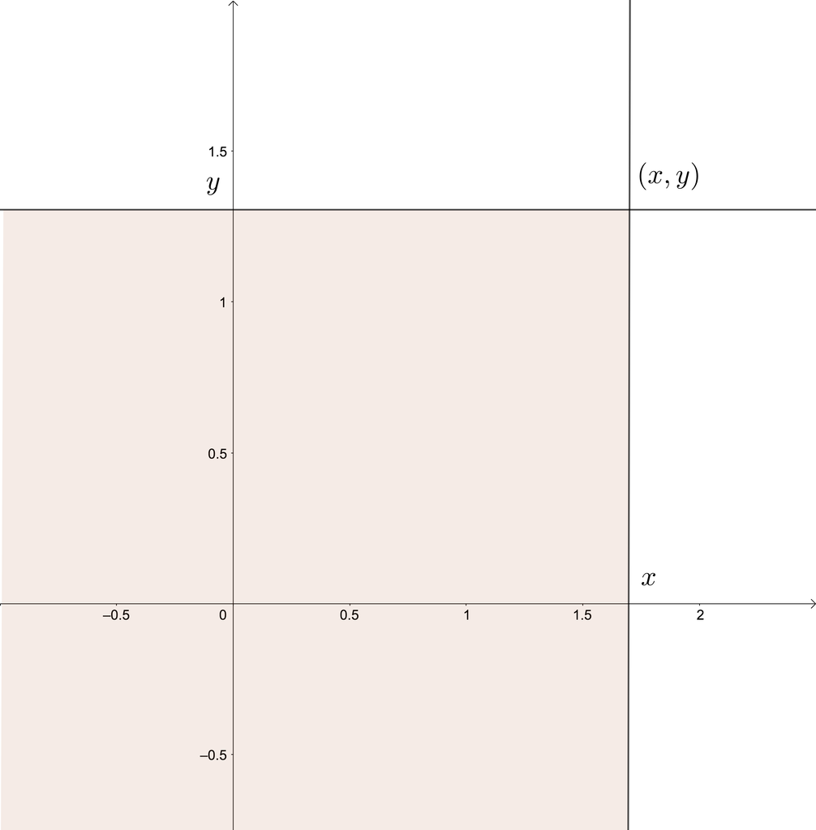

## Función de distribución conjunta. Introducción

Entonces la **función de distribución conjunta** en el valor \((x,y)\) es la probabilidad del suceso formado por aquellos elementos tal que la imagen por la **variable aleatoria bidimensional** \((X,Y)\) caen dentro de la región sombreada en el gráfico anterior:

\[ \begin{array}{rl} F_{XY}(x,y) & =P\{w\in\Omega,\ |\ (X(w),Y(w))\in (-\infty,x]\times (-\infty,y]\} \\ & = P\{w\in\Omega,\ |\ X(w)\leq x,\ Y(w)\leq y\}. \end{array} \]

## Función de distribución conjunta. Propiedades

Sea \((X,Y)\) una variable bidimensional. Sean \(F_{XY}\) su **función de distribución conjunta**. Dicha función satisface las propiedades siguientes:

- La función de distribución conjunta es no decreciente en cada una de las variables: \[ \mbox{Si }x_1\leq x_2, \mbox{ y }y_1\leq y_2,\mbox{ entonces, }F_{XY}(x_1,y_1)\leq F_{XY}(x_2,y_2). \]
- \(F_{XY}(x,-\infty)=F_{XY}(-\infty,y)=0,\) \(F_{XY}(\infty,\infty)=1\), para todo \(x,y\in\mathbb{R}\).

## Función de distribución conjunta. Propiedades

- Las variables aleatorias \(X\) e \(Y\) se llaman **variables aleatorias marginales** y sus funciones de distribución \(F_X\) y \(F_Y\) pueden hallarse de la forma siguiente como función de la **función de distribución conjunta** \(F_{XY}\): \[ F_X(x)=F_{XY}(x,\infty),\ F_Y(y)=F_{XY}(\infty,y), \] para todo \(x,y\in\mathbb{R}\).
- La función de distribución conjunta es continua por el “norte” y por el “este”: \[ \begin{array}{rl} \lim_{x\to a^+}F_{XY}(x,y) & =\lim_{x\to a, x> a}F_{XY}(x,y)=F_{XY}(a,y), \\ \lim_{y\to b^+}F_{XY}(x,y) & =\lim_{y\to b, y> b}F_{XY}(x,y)=F_{XY}(x,b), \end{array} \] para todo \(a,b\in\mathbb{R}\). Ver figura siguiente.

## Función de distribución conjunta. Propiedades

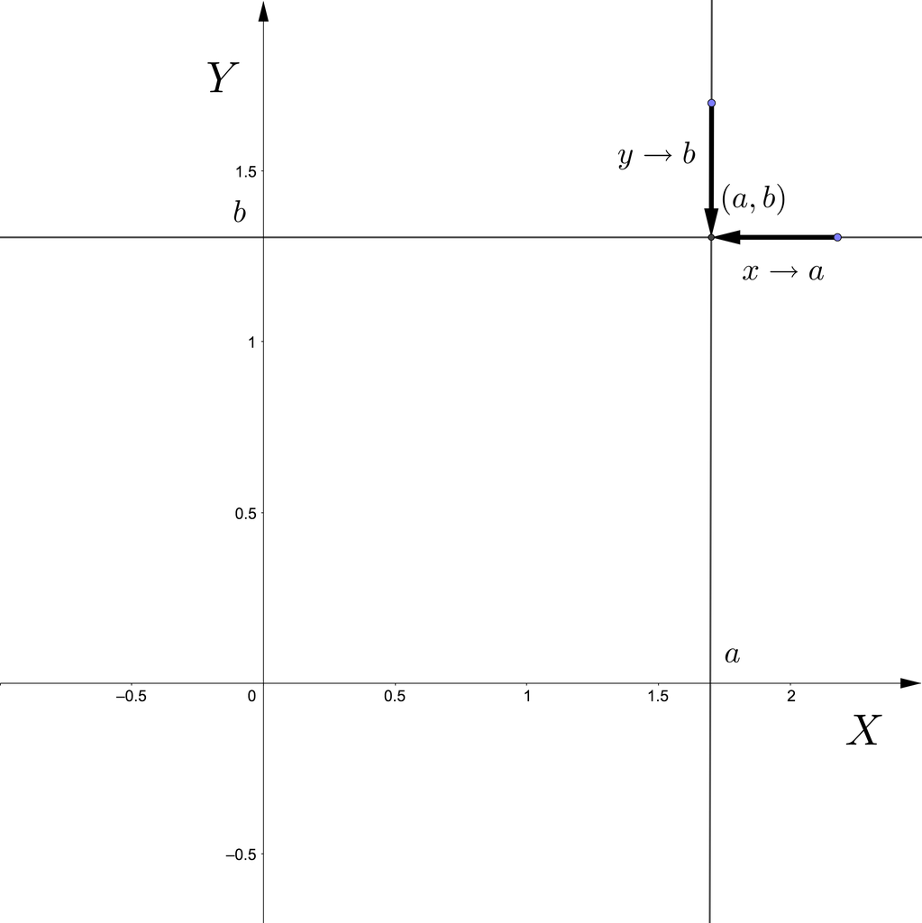

## Función de distribución conjunta. Propiedades

- Dados \(x_1<x_2\) y \(y_1<y_2\), consideramos \(B\) el rectángulo de vértices \((x_1,y_1)\), \((x_1,y_2)\), \((x_2,y_1)\) y \((x_2,y_2)\): \((x_1,x_2]\times (y_1,y_2]\). Entonces, \[ \begin{array}{rl} P((X,Y)\in B) = & F_{XY}(x_2,y_2)-F_{XY}(x_2,y_1)-F_{XY}(x_1,y_2)\\ & +F_{XY}(x_1,y_1). \end{array} \]

## Función de distribución conjunta. Propiedades

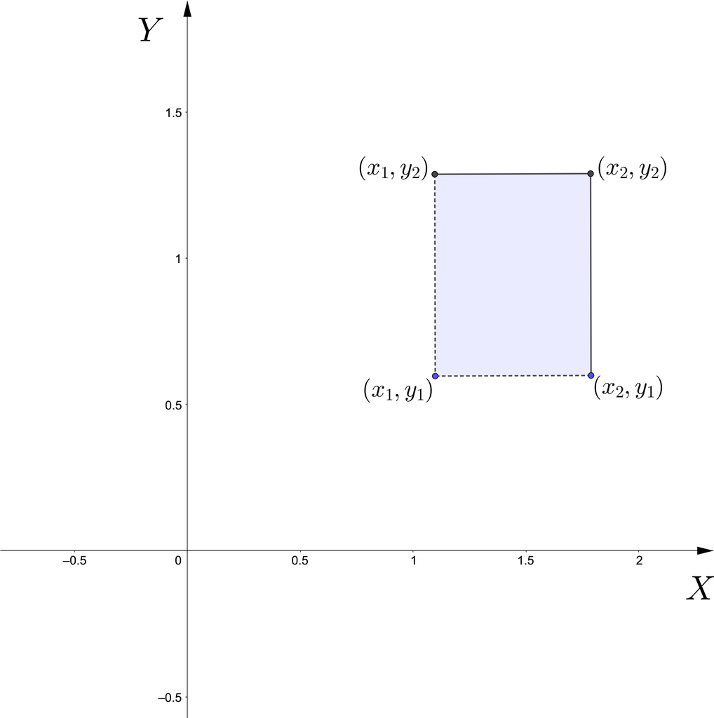

## Función de distribución conjunta. Ejemplo

**Ejemplo**

Consideremos una variable aleatoria bidimensional \((X,Y)\) con **función de distribución conjunta**: \[ F_{XY}(x,y)=\begin{cases} 0, & \mbox{si }x<0,\mbox{ o }y<0,\\ xy, & \mbox{si }0\leq x\leq 1,\ 0\leq y\leq 1, \\ x, & \mbox{si }0\leq x\leq 1,\ y> 1, \\ y, & \mbox{si }0\leq y\leq 1,\ x> 1, \\ 1, & x\geq 1,\ y\geq 1. \end{cases} \] En la figura siguiente, hemos representado por zonas cómo está definida \(F_{XY}\).

## Función de distribución conjunta. Ejemplo

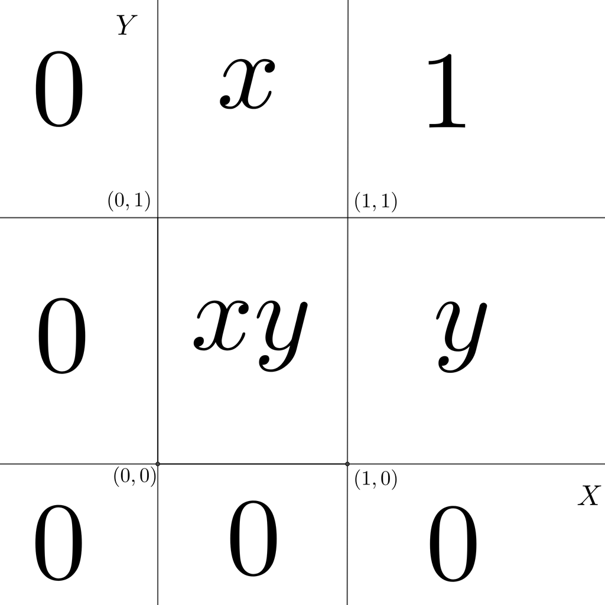

## Función de distribución conjunta. Ejemplo

¿Habéis averiguado cuál es la distribución de \(X\)?

## Función de distribución conjunta. Ejemplo

¡Efectivamente!, \(X\) es la uniforme en el intervalo \((0,1)\).

Dejamos como ejercicio hallar la distribución marginal para la variable \(Y\).

- Comprobemos que \(F_{XY}\) es continua por el “norte” y el “este” en el punto \((1,1)\) que sería un punto problemático: \[ \lim_{x\to 1,x> 1} F_{XY}(x,1)=\lim_{x\to 1,x> 1} 1 = F_{XY}(1,1),\ \lim_{y\to 1,y> 1} F_{XY}(1,y)=\lim_{y\to 1,y> 1} 1 = F_{XY}(1,1). \]

## Función de distribución conjunta. Ejemplo

**Ejemplo: lanzamiento de dos dados no trucados**

Consideremos el experimento aleatorio de lanzar dos dados no trucados.

Sea \((S,P)\) la **variable aleatoria bidimensional** que nos da la suma y el producto de los resultados obtenidos, respectivamente.

La **función de distribución conjunta** en el valor \((3,4)\) será: \[ F_{XY}(3,4) = P(S\leq 3,\ P\leq 4)=P\{(1,1), (1,2), (2,1) \}=\frac{3}{36}=\frac{1}{12}\approx 0.083, \] ya que \(\Omega\) tiene en total \(36\) resultados: \[ \Omega =\{(1,1),(1,2).\ldots, (6,6)\}. \] y los únicos resultados en los que la suma es menor o igual que 3 y el producto menor o igual que 4 son \((1,1)\) (suma 2 producto 1), \((1,2)\) (suma 3 y producto 2) y \((2,1)\) (suma 3 y producto 2).

## Función de distribución conjunta. Ejemplo

**Ejercicio**

Hallar el valor de la **función de distribución conjunta** para la **variable aleatoria bidimensional** anterior \((S,P)\) en los valores \((i,j)\) siguientes: \((4,5),\ (4,9),\ (5,9),\ (6,10)\).

## Variables aleatorias bidimensionales discretas

## Variables aleatorias bidimensionales discretas. Introducción

Definición de variable aleatoria bidimensional discreta: Sea \((X,Y)\) una **variable aleatoria bidimensional**. Diremos que es discreta cuando su conjunto de valores en \(\mathbb{R}^2\), \((X,Y)(\Omega)\) es un conjunto finito o numerable.

En la mayoría de los casos, dicho conjunto será un subconjunto de los enteros naturales.

## Variables aleatorias bidimensionales discretas. Ejemplo

**Ejemplo**

La variable aleatoria bidimensional anterior que nos daba la suma y el producto de los resultados obtenidos por los dos dados, respectivamente es discreta ya que: \[ \begin{array}{rl} (S,P)(\Omega) & =\{(2,1),(3,2),(4,3),(4,4),(5,4),(5,6),(6,5),(6,8),(6,9),(7,6),(7,10),(7,12),(8,12),\\ & (8,15),(8,16),(9,18),(9,20),(10,24),(10,25),(11,30),(12,36)\}. \end{array} \]

## Variables aleatorias bidimensionales discretas. Ejemplo

**Ejercicio**

Comprobar que el conjunto \((S,P)(\Omega)\) dado por el ejemplo coincide con la expresión dada. O sea, hallar el conjunto \((S,P)(\Omega)\): \[ \begin{array}{rl} (S,P): \Omega & \longrightarrow \mathbb{R}^2\\ (1,1) & \longrightarrow (S(1,1),P(1,1))=(2,1),\\ (1,2) & \longrightarrow (S(1,2),P(1,2))=(3,2),\\ \vdots & \vdots \\ (6,6) & \longrightarrow (S(6,6),P(6,6))=(12,36). \end{array} \]

## Función de probabilidad conjunta

Definición de función de probabilidad conjunta: Dada una **variable aleatoria bidimensional discreta** \((X,Y)\) con \((X,Y)(\Omega)=\{(x_i,y_j),\ i=1,2,\ldots,\ j=1,2,\ldots,\}\), definimos la función de probabilidad discreta \(P_{XY}\) para un valor \((x,y)\in\mathbb{R}^2\) de la siguiente forma: \[ \begin{array}{rl} P_{XY}: \mathbb{R}^2 & \longrightarrow \mathbb{R}\\ (x,y) & \longrightarrow P_{XY}(x,y)=P(X= x,\ Y= y). \end{array} \]

Observación: Si \((x,y)\not\in (X,Y)(\Omega)\), el valor de la **función de probabilidad conjunta** en \((x,y)\) en nulo: \(P_{XY}(x,y)=0\), ya que, en este caso, el conjunto \(\{w\in\Omega,\ | (X(w),Y(w))=(x,y)\}=\emptyset\) ya que recordemos \((x,y)\not\in (X,Y)(\Omega)\).

## Función de probabilidad conjunta

Por tanto, de cara a calcular \(P_{XY}\) basta calcular \(P_{XY}(x_i,y_j)\) para \((x_i,y_j)\in (X,Y)(\Omega)\):

| \(X/Y\) | \(y_1\) | \(y_2\) | \(\ldots\) | \(y_N\) |
| --- | --- | --- | --- | --- |
| \(x_1\) | \(P_{XY}(x_1,y_1)\) | \(P_{XY}(x_1,y_2)\) | \(\ldots\) | \(P_{XY}(x_1,y_N)\) |
| \(x_2\) | \(P_{XY}(x_2,y_1)\) | \(P_{XY}(x_2,y_2)\) | \(\ldots\) | \(P_{XY}(x_2,y_N)\) |
| \(\vdots\) | \(\vdots\) | \(\vdots\) | \(\vdots\) | \(\vdots\) |
| \(x_M\) | \(P_{XY}(x_M,y_1)\) | \(P_{XY}(x_M,y_2)\) | \(\ldots\) | \(P_{XY}(x_M,y_N)\) |

## Función de probabilidad conjunta. Ejemplo

**Ejemplo de la suma y el producto de los resultados del lanzamiento de dos dados**

La **función de probabilidad conjunta** será:

| \(S/P\) | 1 | 2 | 3 | 4 | 5 | 6 | 8 | 9 | 10 | 12 | 15 | 16 | 18 | 20 | 24 | 25 | 30 | 36 |
| --- | --- | --- | --- | --- | --- | --- | --- | --- | --- | --- | --- | --- | --- | --- | --- | --- | --- | --- |
| 2 | \(\frac{1}{36}\) | 0 | 0 | 0 | 0 | 0 | 0 | 0 | 0 | 0 | 0 | 0 | 0 | 0 | 0 | 0 | 0 | 0 |
| 3 | 0 | \(\frac{2}{36}\) | 0 | 0 | 0 | 0 | 0 | 0 | 0 | 0 | 0 | 0 | 0 | 0 | 0 | 0 | 0 | 0 |
| 4 | 0 | 0 | \(\frac{2}{36}\) | \(\frac{1}{36}\) | 0 | 0 | 0 | 0 | 0 | 0 | 0 | 0 | 0 | 0 | 0 | 0 | 0 | 0 |
| 5 | 0 | 0 | 0 | \(\frac{2}{36}\) | 0 | \(\frac{2}{36}\) | 0 | 0 | 0 | 0 | 0 | 0 | 0 | 0 | 0 | 0 | 0 | 0 |
| 6 | 0 | 0 | 0 | 0 | \(\frac{2}{36}\) | 0 | \(\frac{2}{36}\) | \(\frac{1}{36}\) | 0 | 0 | 0 | 0 | 0 | 0 | 0 | 0 | 0 | 0 |

## Función de probabilidad conjunta. Ejemplo

| \(S/P\) | 1 | 2 | 3 | 4 | 5 | 6 | 8 | 9 | 10 | 12 | 15 | 16 | 18 | 20 | 24 | 25 | 30 | 36 |
| --- | --- | --- | --- | --- | --- | --- | --- | --- | --- | --- | --- | --- | --- | --- | --- | --- | --- | --- |
| 7 | 0 | 0 | 0 | 0 | 0 | \(\frac{2}{36}\) | 0 | 0 | \(\frac{2}{36}\) | \(\frac{2}{36}\) | 0 | 0 | 0 | 0 | 0 | 0 | 0 | 0 |
| 8 | 0 | 0 | 0 | 0 | 0 | 0 | 0 | 0 | 0 | \(\frac{2}{36}\) | \(\frac{2}{36}\) | \(\frac{1}{36}\) | 0 | 0 | 0 | 0 | 0 | 0 |
| 9 | 0 | 0 | 0 | 0 | 0 | 0 | 0 | 0 | 0 | 0 | 0 | 0 | \(\frac{2}{36}\) | \(\frac{2}{36}\) | 0 | 0 | 0 | 0 |
| 10 | 0 | 0 | 0 | 0 | 0 | 0 | 0 | 0 | 0 | 0 | 0 | 0 | 0 | 0 | \(\frac{2}{36}\) | \(\frac{1}{36}\) | 0 | 0 |
| 11 | 0 | 0 | 0 | 0 | 0 | 0 | 0 | 0 | 0 | 0 | 0 | 0 | 0 | 0 | 0 | 0 | \(\frac{2}{36}\) | 0 |
| 12 | 0 | 0 | 0 | 0 | 0 | 0 | 0 | 0 | 0 | 0 | 0 | 0 | 0 | 0 | 0 | 0 | 0 | \(\frac{1}{36}\) |

## Propiedades de la función de probabilidad conjunta

Sea \((X,Y)\) una **variable aleatoria bidimensional discreta** con conjunto de valores \((X,Y)(\Omega)=\{(x_i,y_j)\, i=1,2,\ldots,\ j=1,2,\ldots\}\). Entonces su **función de probabilidad conjunta** verifica las propiedades siguientes:

La suma de todos los valores de la **función de probabilidad conjunta** sobre el conjunto de valores siempre vale 1: \[\sum_{i}\sum_j P_{XY}(x_i,y_j)=1.\]

## Propiedades de la función de probabilidad conjunta

Sea \(B\) una región del plano. El valor de la probabilidad \(P((X,Y)\in B)\) se puede calcular de la forma siguiente: \[ P((X,Y)\in B) =\sum_{(x_i,y_j)\in B} P_{XY}(x_i,y_j). \] O sea, la probabilidad de que la variable bidimensional coja valores en \(B\) es igual a la suma de todos aquellos valores de la función de probabilidad conjunta que están en \(B\).

## Propiedades de la función de probabilidad conjunta

En particular, tenemos la relación siguiente que relaciona la **función de distribución conjunta** con la **función de probabilidad conjunta**: \[ F_{XY}(x,y)=\sum_{x_i\leq x, y_j\leq y} P_{XY}(x_i,y_j). \] Dicha expresión se deduce de la expresión anterior considerando \(B=(-\infty,x]\times (-\infty,y]\).

## Propiedades de la función de probabilidad conjunta. Ejemplo

**Ejemplo de la suma y el producto de los resultados del lanzamiento de dos dados**

**Ejercicio**

Comprobad usando la tabla de la función de probabilidad conjunta que la suma de todos sus valores suma 1.

Apliquemos la fórmula que relaciona la función de distribución conjunta con la función de probabilidad conjunta para \((x,y)=(5,4)\).

Recordemos la tabla de la función de probabilidad conjunta hasta \(S=5\) y \(P=4\):

## Propiedades de la función de probabilidad conjunta. Ejemplo

| \(S/P\) | 1 | 2 | 3 | 4 |  |
| --- | --- | --- | --- | --- | --- |
| 2 | \(\frac{1}{36}\) | 0 | 0 | 0 | \(\ldots\) |
| 3 | 0 | \(\frac{2}{36}\) | 0 | 0 | \(\ldots\) |
| 4 | 0 | 0 | \(\frac{2}{36}\) | \(\frac{1}{36}\) | \(\ldots\) |
| 5 | 0 | 0 | 0 | \(\frac{2}{36}\) | \(\ldots\) |
| \(\vdots\) | \(\vdots\) | \(\vdots\) | \(\vdots\) | \(\vdots\) | \(\vdots\) |

## Propiedades de la función de probabilidad conjunta. Ejemplo

Observamos que los únicos valores \((x_i,y_j)\in (X,Y)(\Omega)\) que verifican \(x_i\leq 5\) y \(y_j\leq 4\) son \((2,1)\), \((3,2)\), \((4,3)\), \((4,4)\) y \((5,4)\). Por tanto, \[ \begin{array}{rl} F_{SP}(5,4) & = P_{SP}(2,1)+P_{SP}(3,2)+P_{SP}(4,3)+P_{SP}(4,4)+P_{SP}(5,4) \\ & = \frac{1}{36}+\frac{2}{36}+\frac{2}{36}+\frac{1}{36}+\frac{2}{36} = \frac{8}{36}=\frac{2}{9}. \end{array} \] O sea, “a la larga”, de cada 9 veces que lanzamos dos dados, 2 veces obtenemos un resultado cuya suma es menor o igual que 5 y cuyo producto es menor o igual que 4.

## Variables aleatorias marginales

Consideremos una variable aleatoria **bidimensional discreta \((X,Y)\)** con **función de probabilidad conjunta** \(P_{XY}(x_i,y_j)\), con \((x_i,y_j)\in (X,Y)(\Omega)\), \(i=1,2,\ldots\), \(j=1,2,\ldots\).

La tabla de la **función de probabilidad conjunta** contiene suficiente información para obtener las **funciones de probabilidad** de las variables \(X\) e \(Y\).

Dichas variables \(X\) e \(Y\) se denominan **distribuciones marginales** y sus correspondientes **funciones de probabilidad**, **funciones de probabilidad marginales** \(P_X\) de la variable \(X\) y \(P_Y\) de la variable \(Y\).

Veamos cómo obtener \(P_X\) y \(P_Y\) a partir de la tabla \(P_{XY}\).

## Variables aleatorias marginales

Proposición. Expresión de las funciones de probabilidad marginales. Sea \((X,Y)\) una variable aleatoria **bidimensional discreta** con **función de probabilidad conjunta** \(P_{XY}(x_i,y_j)\), con \((x_i,y_j)\in (X,Y)(\Omega)\), \(i=1,2,\ldots\), \(j=1,2,\ldots\).

Las **funciones de probabilidad marginales** \(P_X(x_i)\) y \(P_Y(y_j)\) se calculan usando las expresiones siguientes: \[ \begin{array}{rl} P_X(x_i) & = \sum_{j=1} P_{XY}(x_i,y_j),\ i=1,2,\ldots,\\ P_Y(y_j) & = \sum_{i=1} P_{XY}(x_i,y_j),\ \ j=1,2,\ldots \end{array} \]

## Variables aleatorias marginales

O sea, si pensamos \(P_{XY}\) como una tabla bidimensional donde en la primera fila están los valores de la variable \(Y\) (\(y_1,y_2,\ldots\)) y en la primera columna están los valores de la variable \(X\) (\(x_1,x_2,\ldots\)), para obtener la **función de probabilidad marginal** de la variable \(X\) en el valor \(x_i\), \(P_X(x_i)\), hay que sumar todos los valores de \(P_{XY}(x_i,y_j)\) correspondientes a la fila \(i\)-ésima y para obtener la **función de probabilidad marginal** de la variable \(Y\) en el valor \(y_j\), \(P_Y(y_j)\), hay que sumar todos los valores de \(P_{XY}(x_i,y_j)\) correspondientes a la columna \(j\)-ésima.

## Variables aleatorias marginales. Ejemplo

**Ejemplo de la suma y el producto de los resultados del lanzamiento de dos dados**

Hallemos la función de probabilidad marginal para la suma de los resultados \(S\) usando la expresión vista: \[ \begin{array}{rl} P_S(2) & = P_{SP}(2,1)=\frac{1}{36},\\ P_S(3) & = P_{SP}(3,2)=\frac{2}{36},\\ P_S(4) & = P_{SP}(4,3)+P_{SP}(4,4)=\frac{2}{36}+\frac{1}{36}=\frac{3}{36}=\frac{1}{12},\\ P_S(5) & = P_{SP}(5,4)+P_{SP}(5,6)=\frac{2}{36}+\frac{2}{36}=\frac{4}{36}=\frac{1}{9},\\ P_S(6) & = P_{SP}(6,5)+P_{SP}(6,8)+P_{SP}(6,9)=\frac{2}{36}+\frac{2}{36}+\frac{1}{36}=\frac{5}{36},\\ P_S(7) & = P_{SP}(7,6)+P_{SP}(7,10)+P_{SP}(7,12)=\frac{2}{36}+\frac{2}{36}+\frac{2}{36}=\frac{6}{36}=\frac{1}{6},\\ P_S(8) & = P_{SP}(8,12)+P_{SP}(8,15)+P_{SP}(8,16)=\frac{2}{36}+\frac{2}{36}+\frac{1}{36}=\frac{5}{36},\\ P_S(9) & = P_{SP}(9,18)+P_{SP}(9,20)=\frac{2}{36}+\frac{2}{36}=\frac{4}{36}=\frac{1}{9},\\ P_S(10) & = P_{SP}(10,24)+P_{SP}(10,25)=\frac{2}{36}+\frac{1}{36}=\frac{3}{36}=\frac{1}{12},\\ P_S(11) & = P_{SP}(11,30)=\frac{2}{36},\\ P_S(12) & = P_{SP}(12,36)=\frac{1}{36}. \end{array} \]

## Variables aleatorias marginales. Ejemplo

La **función de probabilidad marginal** de la suma \(S\) queda resumida en la tabla siguiente:

| \(S\) | 2 | 3 | 4 | 5 | 6 | 7 | 8 | 9 | 10 | 11 | 12 |
| --- | --- | --- | --- | --- | --- | --- | --- | --- | --- | --- | --- |
| \(P_S\) | \(\frac{1}{36}\) | \(\frac{2}{36}\) | \(\frac{3}{36}\) | \(\frac{4}{36}\) | \(\frac{5}{36}\) | \(\frac{6}{36}\) | \(\frac{5}{36}\) | \(\frac{4}{36}\) | \(\frac{3}{36}\) | \(\frac{2}{36}\) | \(\frac{1}{36}\) |

**Ejercicio**

Consideremos el ejemplo anterior de la suma y el producto de los resultados del lanzamiento de dos dados.

Calcular la **función de probabilidad marginal** del producto \(P\) de los resultados.